# Riesgo de cáncer en relación con factores condicionantes de la salud en España

Vanessa Pérez Paredes

Carmen Gómez Peña

2025-01-19

Enlace a repositorio de [Github](https://github.com/vpp1004/SEMINARIO_FUENTES)

### Introducción

En este seminario vamos a estudiar la enfermedad del cáncer y su relación con distintas variables que pueden influir en ella positiva o negativamente en las distintas comunidades de España. En específico, las variables que estudiaremos son los casos de personas que realizan actividad física habitualmente, los casos de consumidores habituales de alcohol y el número de zonas verdes de cada lugar.

### Objetivos

Responder a estas preguntas:

- ¿Cómo influyen individualmente el índice verde, el alcohol y el ejercicio sobre el cáncer?
- ¿Tiene más influencia lo considerado bueno para la salud (ejercicio y porcentaje verde) que lo malo (alcohol) sobre el cáncer?
- ¿Están todas estas variables directamente relacionadas con el cáncer ?

##Instalación de paquetes necesarios para el desarrollo del proyecto Aquí se encuentran los paquetes que hay que instalar para poder ejecutar este proyecto, en caso de tener estos paquetes ya instalados no ha de ejecutarse esta celda. Estos paquetes contienen funciones básicas necesarias para el tratamiento de archivos json y pcaxis que nos permiten desarrollar investigación sobre ellos

```r
###  CARGA DE PAQUETES:
#install.packages("pxR")
#install.packages("tidyverse")
#install.packages("rjson")
#install.packages("tidyjson")
#install.packages("json")
#install.packages("ggplot2")
#install.packages("greenR")
```

### Carga de librerías necesarias para realizar el proyecto

Una vez que se ha producido la instalación de los paquetes para poder realizar cualquier función necesitamos cargar las librerías instaladas para poder utilizarlas. La siguiente celda contiene las librerías necesarias para poder realizar el proyecto.

```r
library(pxR)
library(tidyverse)
library(rjson)
library(tidyjson)
library(jsonlite)
```

```r
library(dplyr)
library(RJSONIO)
library(ggplot2)
library(greenR)
```

### Subida de archivos necesarios

En este proyecto vamos a trabajar con diferentes archivos tanto json como pcaxis,además de trabajar con datos directamente de un repostitorio por tanto necesitamos incluir los archivos para trabajar con ellos.Aqúi se realiza la subida de los objetos y archivos necesarios para desarrollar el proyecto.

```r
load("Objetos.RData")
```

### Carga de datos de consumo de alcohol (pcaxis)

Encontramos los datos de personas que habitualmente consumen alcohol por las diferentes comunidades de España.

```r
casos_alcohol<-read.px("INPUT/DATA/CASOS_ALCOHOL/CasosAlcoholComunidades.px")
dtalcohol<-as.data.frame(casos_alcohol)
alcohol<-select(.data =dtalcohol,value,Consumo.de.bebidas.alcohólicas,Comunidad.autónoma) %>%
  filter(Consumo.de.bebidas.alcohólicas=="Sí ha consumido")
alcohol<-as.data.frame(alcohol)%>%
  select(Comunidad.autónoma,value)
alcohol <- alcohol[alcohol$Comunidad.autónoma != "Total Nacional", ]
alcohol[is.na(alcohol$Comunidad_autonoma) == FALSE, ]
```

```
## [1] Comunidad.autónoma value
## <0 rows> (o 0- extensión row.names)
```

```r
alcohol
```

```
##                Comunidad.autónoma  value
## 2                    01 Andalucía 3775.2
## 3                       02 Aragón  667.3
## 4      03 Asturias, Principado de  654.1
## 5               04 Balears, Illes  632.2
## 6                     05 Canarias 1079.1
## 7                    06 Cantabria  364.4
## 8              07 Castilla y León 1473.9
## 9         08 Castilla - La Mancha 1048.5
## 10                    09 Cataluña 4458.7
## 11        10 Comunitat Valenciana 3058.5
## 12                 11 Extremadura  574.1
## 13                     12 Galicia 1477.1
## 14        13 Madrid, Comunidad de 3964.9
## 15           14 Murcia, Región de  796.0
## 16 15 Navarra, Comunidad Foral de  424.0
## 17                  16 País Vasco 1451.0
## 18                   17 Rioja, La  192.7
## 19                       18 Ceuta   27.0
## 20                     19 Melilla   21.1
```

### Case_when alcohol

```r
alcohol
```

```
##                Comunidad.autónoma  value
## 2                    01 Andalucía 3775.2
## 3                       02 Aragón  667.3
## 4      03 Asturias, Principado de  654.1
## 5               04 Balears, Illes  632.2
## 6                     05 Canarias 1079.1
## 7                    06 Cantabria  364.4
## 8              07 Castilla y León 1473.9
## 9         08 Castilla - La Mancha 1048.5
## 10                    09 Cataluña 4458.7
## 11        10 Comunitat Valenciana 3058.5
## 12                 11 Extremadura  574.1
## 13                     12 Galicia 1477.1
## 14        13 Madrid, Comunidad de 3964.9
## 15           14 Murcia, Región de  796.0
## 16 15 Navarra, Comunidad Foral de  424.0
## 17                  16 País Vasco 1451.0
## 18                   17 Rioja, La  192.7
## 19                       18 Ceuta   27.0
## 20                     19 Melilla   21.1
```

```r
alcohol<-alcohol%>%
  mutate(.data = alcohol,Comunidad_autonoma = case_when(Comunidad.autónoma=="08 Castilla - La Mancha" ~ 'Castilla_LaMancha',
Comunidad.autónoma=="13 Madrid, Comunidad de" ~ 'Madrid',
Comunidad.autónoma=="11 Extremadura"~"Extremadura",
Comunidad.autónoma=="18 Ceuta"~"Ceuta",
Comunidad.autónoma=="19 Melilla"~"Melilla",
Comunidad.autónoma=="04 Balears, Illes"~"Islas_Baleares",
Comunidad.autónoma=="14 Murcia, Región de"~"Murcia",
Comunidad.autónoma=="15 Navarra, Comunidad Foral de"~"Navarra",
Comunidad.autónoma=="10 Comunitat Valenciana"~"Comunidad_Valenciana",
Comunidad.autónoma=="12 Galicia"~"Galicia",
Comunidad.autónoma=="07 Castilla y León"~"Castilla_y_Leon",
Comunidad.autónoma=="09 Cataluña"~"Cataluna",
Comunidad.autónoma=="06 Cantabria"~"Cantabria",
Comunidad.autónoma=="05 Canarias"~"Islas_Canarias",
Comunidad.autónoma=="01 Andalucía"~"Andalucia",
Comunidad.autónoma=="02 Aragón"~"Aragon",
Comunidad.autónoma=="03 Asturias, Principado de"~"Asturias",
Comunidad.autónoma=="17 Rioja, La"~"Rioja",
Comunidad.autónoma=="16 País Vasco"~"Pais_Vasco"
  ))%>%
  select(Comunidad_autonoma,value)
alcohol
```

```
##      Comunidad_autonoma  value
## 2             Andalucia 3775.2
## 3                Aragon  667.3
## 4              Asturias  654.1
## 5        Islas_Baleares  632.2
## 6        Islas_Canarias 1079.1
## 7             Cantabria  364.4
## 8       Castilla_y_Leon 1473.9
## 9     Castilla_LaMancha 1048.5
## 10             Cataluna 4458.7
## 11 Comunidad_Valenciana 3058.5
## 12          Extremadura  574.1
## 13              Galicia 1477.1
## 14               Madrid 3964.9
## 15               Murcia  796.0
## 16              Navarra  424.0
## 17           Pais_Vasco 1451.0
## 18                Rioja  192.7
## 19                Ceuta   27.0
## 20              Melilla   21.1
```

Determinamos ahora cuáles van a ser las comunidades autónomas con mayores casos de alcoholemia y las que menos.

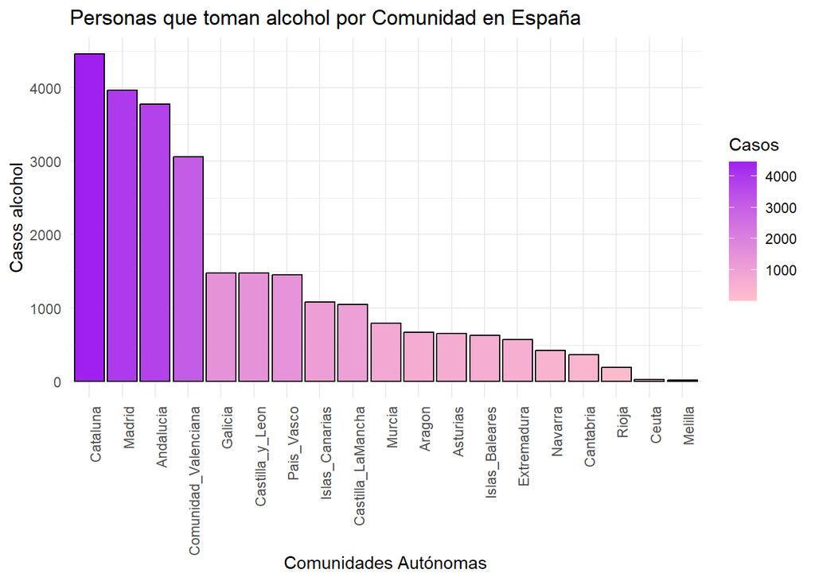

```r
grafico_alcohol <- ggplot(alcohol, aes(x = reorder(Comunidad_autonoma,-value), y = value, fill = value)) +
  geom_bar(stat = "identity", color = "black") +
  scale_fill_gradient(low = "pink", high = "purple") +
  labs(
    title = "Personas que toman alcohol por Comunidad en España",
    x = "Comunidades Autónomas",
    y = "Casos alcohol",
    fill = "Casos"
  ) +
  theme_minimal()+
  theme(axis.text.x =element_text(angle = 90, hjust = 1))
grafico_alcohol
```

Podemos observar que Cataluña, Madrid y Andalucía van a liderar el ranking con las comunidades con mayor número de casos de alcoholemia, mientras que Ceuta y Melilla se encuentran en la cola del ranking. Cabe destacar que al tratarse de número de casos y no de porcentaje, las comunides con mayor población van a ser siempre las que lideren el ranking, determinando que si lo que realmente se hiciera fuera una comparativa de porcentajes, comunidades que se encuentran más a la derecha del ránking tendrían mayor porcentaje que las tres comunidades que lo lideran actualmente

### Carga de datos de casos de cancer (json)

Este archivo contiene el número de casos de cáncer de España ordenados por las diferentes comunidades autónomas.

```r
archivo <-fromJSON("INPUT/DATA/CASOS_CANCER/casos_nuevos_de_cancer.json")
dtcancer<-as.data.frame(archivo$Respuesta$Datos$Metricas$Datos)
cancer<-select(.data=dtcancer,Parametro,Valor)
cancer
```

```
##               Parametro Valor
## 1             Andalucía 49387
## 2                Aragón  8889
## 3              Asturias  7762
## 4              Canarias 12739
## 5             Cantabria  4041
## 6       Castilla y León 18188
## 7    Castilla-La Mancha 12767
## 8              Cataluña 46630
## 9                 Ceuta   380
## 10 Comunidad Valenciana 31928
## 11          Extremadura  7032
## 12              Galicia 20135
## 13       Islas Baleares  6511
## 14             La Rioja  2115
## 15               Madrid 39203
## 16              Melilla   363
## 17               Murcia  8259
## 18              Navarra  4175
## 19           País Vasco 15170
```

### Case_when cancer

```r
cancer<-cancer%>%
        mutate(.data = cancer,Comunidad_autonoma = case_when(
Parametro=="Castilla-La Mancha" ~ 'Castilla_LaMancha',
Parametro=="Madrid" ~ 'Madrid',
Parametro=="Extremadura"~"Extremadura",
Parametro=="Ceuta"~"Ceuta",
Parametro=="Melilla"~"Melilla",
Parametro=="Islas Baleares"~"Islas_Baleares",
Parametro=="Murcia"~"Murcia",
Parametro=="Navarra"~"Navarra",
Parametro=="Comunidad Valenciana"~"Comunidad_Valenciana",
Parametro=="Galicia"~"Galicia",
Parametro=="Castilla y León"~"Castilla_y_Leon",
Parametro=="Cataluña"~"Cataluna",
Parametro=="Cantabria"~"Cantabria",
Parametro=="Canarias"~"Islas_Canarias",
Parametro=="Andalucía"~"Andalucia",
Parametro=="Aragón"~"Aragon",
Parametro=="Asturias"~"Asturias",
Parametro=="La Rioja"~"Rioja",
Parametro=="País Vasco"~"Pais_Vasco"
 ))%>%
  select(Comunidad_autonoma,Valor)
cancer
```

```
##      Comunidad_autonoma Valor
## 1             Andalucia 49387
## 2                Aragon  8889
## 3              Asturias  7762
## 4        Islas_Canarias 12739
## 5             Cantabria  4041
## 6       Castilla_y_Leon 18188
## 7     Castilla_LaMancha 12767
## 8              Cataluna 46630
## 9                 Ceuta   380
## 10 Comunidad_Valenciana 31928
## 11          Extremadura  7032
## 12              Galicia 20135
## 13       Islas_Baleares  6511
## 14                Rioja  2115
## 15               Madrid 39203
## 16              Melilla   363
## 17               Murcia  8259
## 18              Navarra  4175
## 19           Pais_Vasco 15170
```

Observamos cuáles son las comunidades que tienen mayores casos de cáncer y cuáles son las que menos.

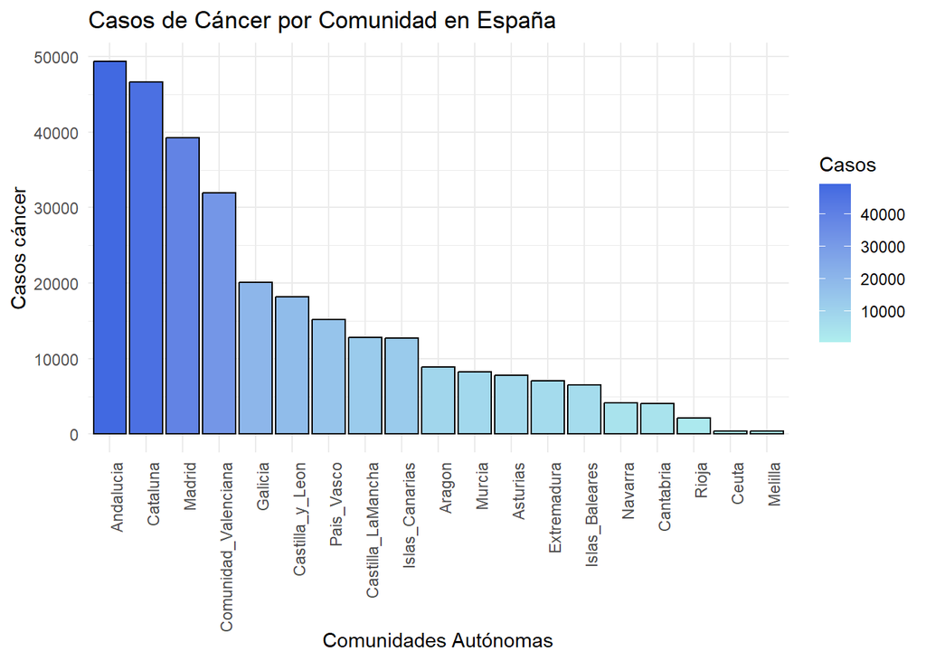

```r
grafico_cancer <- ggplot(cancer, aes(x =reorder(Comunidad_autonoma,-Valor), y = Valor, fill = Valor)) +
  geom_bar(stat = "identity", color = "black") +
  scale_fill_gradient(low = "paleturquoise", high = "royalblue") +
  labs(
    title = "Casos de Cáncer por Comunidad en España",
    x = "Comunidades Autónomas",
    y = "Casos cáncer",
    fill = "Casos"
  ) +
  theme_minimal()+
  theme(axis.text.x =element_text(angle = 90, hjust = 1))
grafico_cancer
```

Podemos observar que Cataluña, Madrid y Andalucía van a liderar el ranking con las comunidades con mayor número de casos de cáncer, mientras que Ceuta y Melilla se encuentran en la cola del ranking.Cabe destacar que al tratarse de número de casos y no de porcentaje, las comunides con mayor población van a ser siempre las que lideren el ranking, determinando que si lo que realmente se hiciera fuera una comparativa de porcentajes, comunidades que se encuentran más a la derecha del ránking tendrían mayor porcentaje que las tres comunidades que lo lideran actualmente.

### Carga de datos de porcentaje verde por comunidades

Se han obtenido los datos a partir de un repositorio de Github.Para ello, hemos obtenido datos a partir de diferentes municipios de la comunidad. Insercción de un ejemplo de cómo se han obtenido los datos de un municipio.

```r
#datostorrelavega<-get_osm_data("Torrelavega,Cantabria,España")
#indice_verde_torrelavega<-calculate_green_index(datostorrelavega,4326,100)
#dttorrelavega<-as.data.frame(indice_verde_torrelavega)
#torrelavega<-summarise(.data=dttorrelavega,areasverdes=mean(green_index_green_area,na.rm=TRUE),arboles=mean(green_index_tree,na.rm=TRUE),porcentajeverde=mean(green_index,na.rm=TRUE))
```

Aquí se encuentra la tabla completa tras haber realizado todo esto por comunidades autónomas.

```r
zonas_verdes
```

```
##      Comunidad_autonoma porcentajeverde
## 1             Andalucia       0.8320185
## 2                Aragon       0.7636759
## 3              Asturias       0.8087230
## 4        Islas_Baleares       0.8078401
## 5        Islas_Canarias       0.8521385
## 6             Cantabria       0.8445879
## 7       Castilla_y_Leon       0.7810239
## 8     Castilla_LaMancha       0.7934108
## 9              Cataluna       0.8137199
## 10          Extremadura       0.8558643
## 11              Galicia       0.7800792
## 12               Madrid       0.8381101
## 13               Murcia       0.8127904
## 14              Navarra       0.7445773
## 15           Pais_Vasco       0.7783241
## 16                Rioja       0.7494397
## 17 Comunidad_Valenciana       0.8034498
## 18                Ceuta       0.9473913
## 19              Melilla       0.9473913
```

Determinamos ahora que a pesar de rondar entre los mismos valores, cuáles son las comunidades españolas que tienen mayor porcentaje de índice verde y cuáles son las que menos.

```r
zonas_verdes
```

```
##      Comunidad_autonoma porcentajeverde
## 1             Andalucia       0.8320185
## 2                Aragon       0.7636759
## 3              Asturias       0.8087230
## 4        Islas_Baleares       0.8078401
## 5        Islas_Canarias       0.8521385
## 6             Cantabria       0.8445879
## 7       Castilla_y_Leon       0.7810239
## 8     Castilla_LaMancha       0.7934108
## 9              Cataluna       0.8137199
## 10          Extremadura       0.8558643
## 11              Galicia       0.7800792
## 12               Madrid       0.8381101
## 13               Murcia       0.8127904
## 14              Navarra       0.7445773
## 15           Pais_Vasco       0.7783241
## 16                Rioja       0.7494397
## 17 Comunidad_Valenciana       0.8034498
## 18                Ceuta       0.9473913
## 19              Melilla       0.9473913
```

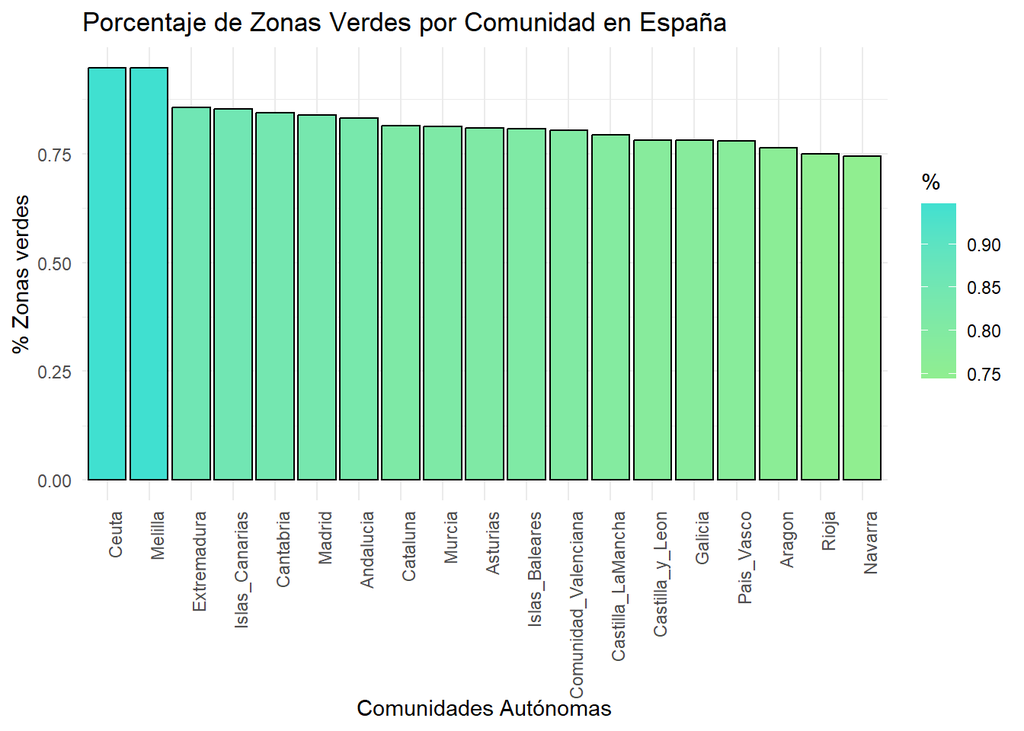

```r
grafico_zonas_verdes <- ggplot(zonas_verdes, aes(reorder(Comunidad_autonoma,-porcentajeverde), y = porcentajeverde, fill = porcentajeverde)) +
  geom_bar(stat = "identity", color = "black") +
  scale_fill_gradient(low = "lightgreen", high = "turquoise") +
  labs(
    title = "Porcentaje de Zonas Verdes por Comunidad en España",
    x = "Comunidades Autónomas",
    y = "% Zonas verdes",
    fill = "%"
  ) +
  theme_minimal()+
  theme(axis.text.x =element_text(angle = 90, hjust = 1))

grafico_zonas_verdes
```

### Carga de datos ejercicios físico

Este archivo contiene el número de personas que realizan ejercicio físico en España ordenados por comunidades.

```r
actividadfisica<-"INPUT/DATA/EJERCICIO FISICo/Porcentaje actividad física por comunidad.px"
datosactividad<-read.px(actividadfisica)
dtactividad<-as.data.frame(datosactividad)
actividad<-select(.data=dtactividad,Comunidades.y.Ciudades.Autónomas,value)
actividad <- actividad[actividad$Comunidades.y.Ciudades.Autónomas != "Total Nacional", ]
actividad
```

```
##    Comunidades.y.Ciudades.Autónomas value
## 2                      01 Andalucía  35.3
## 3                         02 Aragón  42.2
## 4        03 Asturias, Principado de  43.7
## 5                 04 Balears, Illes  36.2
## 6                       05 Canarias  35.7
## 7                      06 Cantabria  42.2
## 8                07 Castilla y León  43.7
## 9           08 Castilla - La Mancha  40.0
## 10                      09 Cataluña  35.3
## 11          10 Comunitat Valenciana  34.2
## 12                   11 Extremadura  44.1
## 13                       12 Galicia  35.0
## 14          13 Madrid, Comunidad de  41.5
## 15             14 Murcia, Región de  28.6
## 16   15 Navarra, Comunidad Foral de  42.3
## 17                    16 País Vasco  42.3
## 18                     17 Rioja, La  41.2
## 19                         18 Ceuta  41.9
## 20                       19 Melilla  45.7
```

### Case_when actividad

Para poder realizar la unión de la actividad con el resto necesitamos realizar un case_when que nos permita obtener los parámetros de actividad igual que los del resto. Como estamos realizando una unión por comunidades en este caso vamos a cambiar estos nombres para poder realizar una unión posteriormente.

```r
ctividad<-actividad%>%
  mutate(.data = actividad,Comunidad_autonoma = case_when(
Comunidades.y.Ciudades.Autónomas=="08 Castilla - La Mancha" ~ 'Castilla_LaMancha',
Comunidades.y.Ciudades.Autónomas=="13 Madrid, Comunidad de" ~ 'Madrid',
Comunidades.y.Ciudades.Autónomas=="11 Extremadura"~"Extremadura",
Comunidades.y.Ciudades.Autónomas=="18 Ceuta"~"Ceuta",
Comunidades.y.Ciudades.Autónomas=="19 Melilla"~"Melilla",
Comunidades.y.Ciudades.Autónomas=="04 Balears, Illes"~"Islas_Baleares",
Comunidades.y.Ciudades.Autónomas=="14 Murcia, Región de "~"Murcia",
Comunidades.y.Ciudades.Autónomas=="15 Navarra,Comunidad Foral de"~"Navarra",
Comunidades.y.Ciudades.Autónomas=="10 Comunitat Valenciana"~"Comunidad_Valenciana",
Comunidades.y.Ciudades.Autónomas=="12 Galicia"~"Galicia",
Comunidades.y.Ciudades.Autónomas=="07 Castilla y León"~"Castilla_y_Leon",
Comunidades.y.Ciudades.Autónomas=="09 Cataluña"~"Cataluna",
Comunidades.y.Ciudades.Autónomas=="06 Cantabria"~"Cantabria",
Comunidades.y.Ciudades.Autónomas=="05 Canarias"~"Islas_Canarias",
Comunidades.y.Ciudades.Autónomas=="01 Andalucía"~"Andalucia",
Comunidades.y.Ciudades.Autónomas=="02 Aragón"~"Aragon",
Comunidades.y.Ciudades.Autónomas=="03 Asturias, Principado de"~"Asturias",
Comunidades.y.Ciudades.Autónomas=="17 Rioja, La"~"Rioja",
Comunidades.y.Ciudades.Autónomas=="16 País Vasco"~"Pais_Vasco"
  ))%>%
  select(Comunidad_autonoma,value)
actividad<-ctividad
actividad
```

```
##      Comunidad_autonoma value
## 2             Andalucia  35.3
## 3                Aragon  42.2
## 4              Asturias  43.7
## 5        Islas_Baleares  36.2
## 6        Islas_Canarias  35.7
## 7             Cantabria  42.2
## 8       Castilla_y_Leon  43.7
## 9     Castilla_LaMancha  40.0
## 10             Cataluna  35.3
## 11 Comunidad_Valenciana  34.2
## 12          Extremadura  44.1
## 13              Galicia  35.0
## 14               Madrid  41.5
## 15                 <NA>  28.6
## 16                 <NA>  42.3
## 17           Pais_Vasco  42.3
## 18                Rioja  41.2
## 19                Ceuta  41.9
## 20              Melilla  45.7
```

Determinamos ahora las comunidades en las que tenemos mayor porcentaje de ejercicio físico ordenadas de mayor a menor.

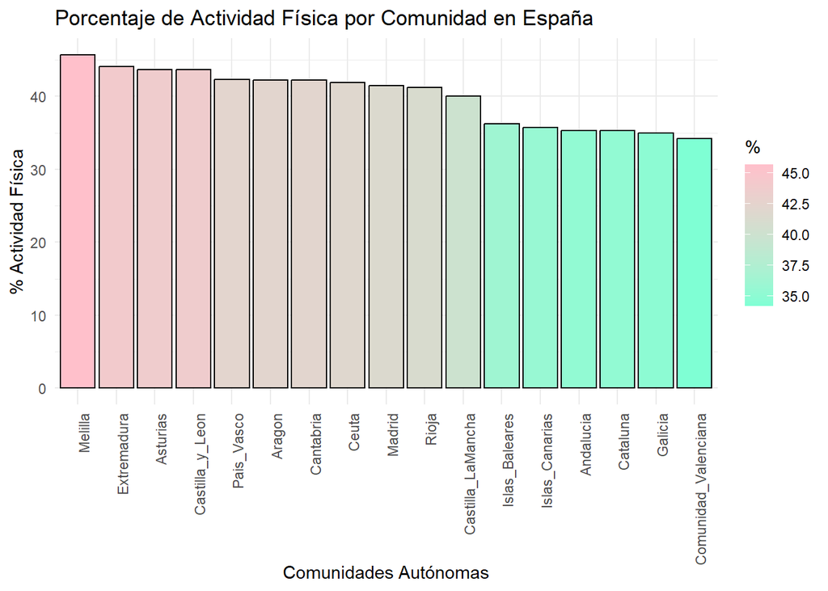

```r
actividad<-na.omit(actividad)
grafico_actividad_fisica <- ggplot(actividad, aes(x =reorder(Comunidad_autonoma,-value), y = value, fill = value)) +
  geom_bar(stat = "identity", color = "black") +
  scale_fill_gradient(low = "aquamarine", high = "pink") +
  labs(
    title = "Porcentaje de Actividad Física por Comunidad en España",
    x = "Comunidades Autónomas",
    y = "% Actividad Física",
    fill = "%"
  ) +
  theme_minimal()+
  theme(axis.text.x =element_text(angle = 90, hjust = 1))
grafico_actividad_fisica
```

### Como influyen individualmente las variables

### CASOS DE CÁNCER INFLUIDOS POR ALCOHOL

Vamos a ver la correlación que tiene el cáncer con la cantidad de alcohol ingerido. Para ello, vamos a tomar de parámetro de unión las comunidades autónomas de España que nos permitan realizar la correlación de cómo realmente se relacionan.

```r
alcohol_cancer<-full_join(x=alcohol,y=cancer,by=c("Comunidad_autonoma"))%>%
  rename(casos_alcohol=value,casos_cancer=Valor)
alcohol_cancer <- alcohol_cancer[is.na(alcohol_cancer$Comunidad_autonoma) == FALSE, ]
alcohol_cancer
```

```
##      Comunidad_autonoma casos_alcohol casos_cancer
## 1             Andalucia        3775.2        49387
## 2                Aragon         667.3         8889
## 3              Asturias         654.1         7762
## 4        Islas_Baleares         632.2         6511
## 5        Islas_Canarias        1079.1        12739
## 6             Cantabria         364.4         4041
## 7       Castilla_y_Leon        1473.9        18188
## 8     Castilla_LaMancha        1048.5        12767
## 9              Cataluna        4458.7        46630
## 10 Comunidad_Valenciana        3058.5        31928
## 11          Extremadura         574.1         7032
## 12              Galicia        1477.1        20135
## 13               Madrid        3964.9        39203
## 14               Murcia         796.0         8259
## 15              Navarra         424.0         4175
## 16           Pais_Vasco        1451.0        15170
## 17                Rioja         192.7         2115
## 18                Ceuta          27.0          380
## 19              Melilla          21.1          363
```

Como podemos observar, las comunidades que presentan más casos de cáncer son aquellas en las que más alcohol toman, siendo principalmente destacables comunidades con gran número de gente alcohólica, como es el caso de Madrid, Cataluña o Andalucía, donde tanto el número de casos de alcohol y de cáncer son elevados. Sin embargo, otras comunidades como es el caso de Cantabria o Navarra presentan mucha menos cantidad de casos de alcoholismo y vemos como considerablemente se presentan muchos menos casos de cáncer. Para ver si realmente esto está correlacionado observamos un gráfico de correlación de estas dos variables.

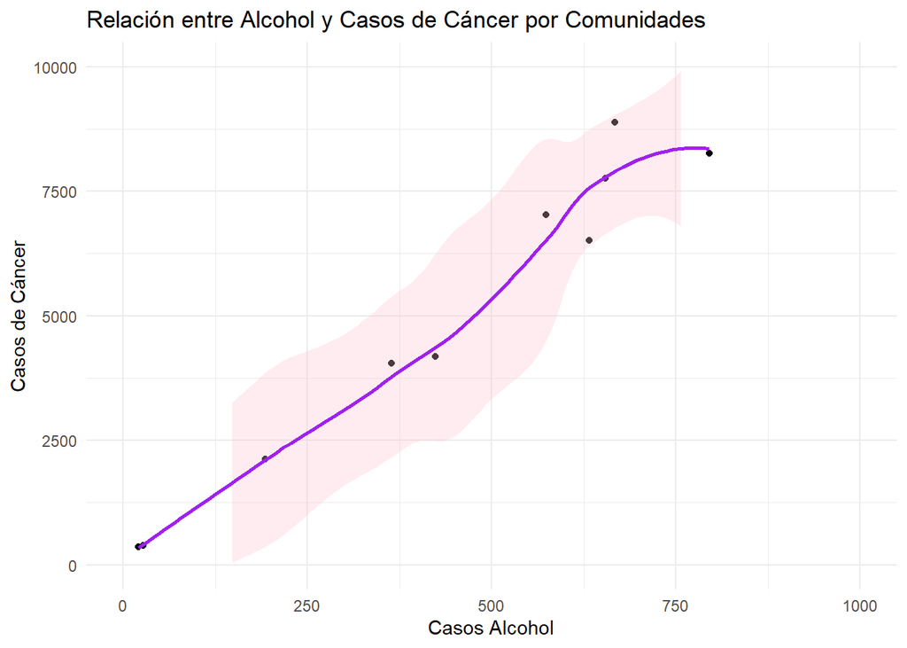

```r
grafico_alcohol_cancer <- ggplot(alcohol_cancer, aes(x = casos_alcohol, y = casos_cancer)) +
  geom_point() +
  labs(
    title = "Relación entre Alcohol y Casos de Cáncer por Comunidades",
    x = "Casos Alcohol",
    y = "Casos de Cáncer"
  ) +
  geom_smooth(method = "loess", formula = y ~ x, color = "purple", fill = "pink", alpha = 0.3)+
  xlim(0, 1000) +
  ylim(0, 10000) +
  theme_minimal()
grafico_alcohol_cancer
```

Como podemos comprobar, a mayor casos de alcohol tenemos que el número de casos de cáncer es mayor. Por tanto, podemos definir que estas dos variable están directamente relacionadas.

### CASOS DE CÁNCER INFLUIDOS POR EJERCICIO FISICO

Vamos a ver la correlación que tiene el cáncer con el porcentaje medio de ejercicio físico que se realiza. Para ello, vamos a tomar de parámetro de unión las comunidades autónomas de España que nos permitan realizar la observación de cómo realmente se relacionan.

```r
actividad_cancer<- full_join(x=actividad,y=cancer,by=c("Comunidad_autonoma"))%>%
                  rename(actividad=value,casos_cancer=Valor)
actividad_cancer <- actividad_cancer[is.na(actividad_cancer$Comunidad_autonoma) == FALSE, ]
actividad_cancer
```

```
##      Comunidad_autonoma actividad casos_cancer
## 1             Andalucia      35.3        49387
## 2                Aragon      42.2         8889
## 3              Asturias      43.7         7762
## 4        Islas_Baleares      36.2         6511
## 5        Islas_Canarias      35.7        12739
## 6             Cantabria      42.2         4041
## 7       Castilla_y_Leon      43.7        18188
## 8     Castilla_LaMancha      40.0        12767
## 9              Cataluna      35.3        46630
## 10 Comunidad_Valenciana      34.2        31928
## 11          Extremadura      44.1         7032
## 12              Galicia      35.0        20135
## 13               Madrid      41.5        39203
## 14           Pais_Vasco      42.3        15170
## 15                Rioja      41.2         2115
## 16                Ceuta      41.9          380
## 17              Melilla      45.7          363
## 18               Murcia        NA         8259
## 19              Navarra        NA         4175
```

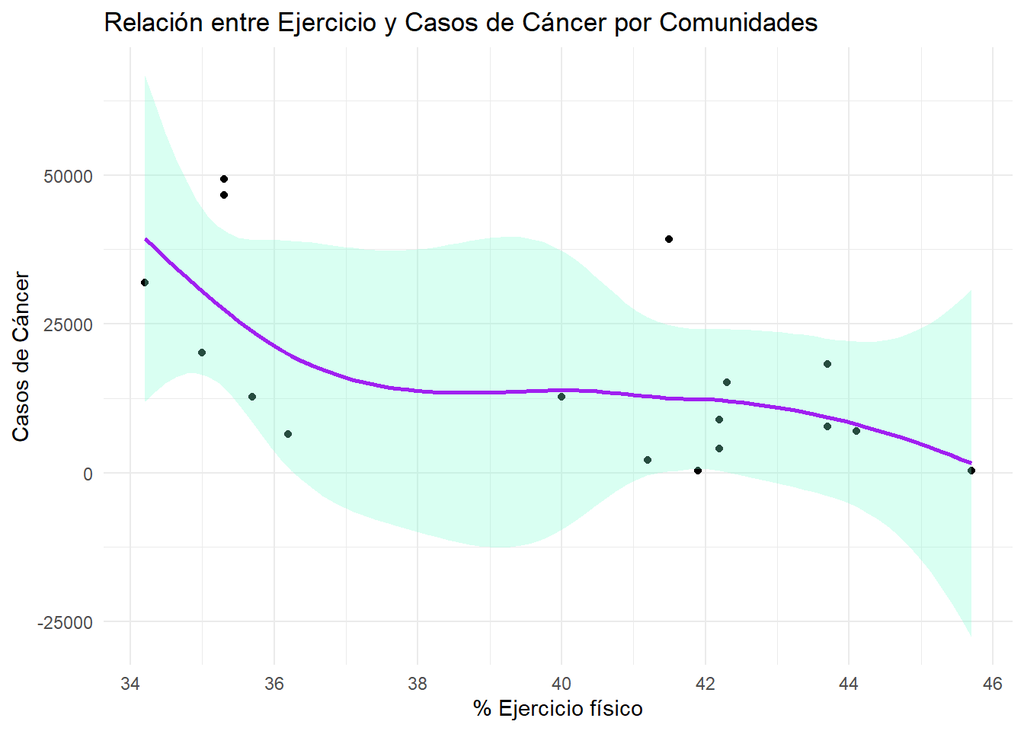

```r
gráfico_ejercicio_cancer <- ggplot(actividad_cancer, aes(x = actividad, y = casos_cancer)) +
  geom_point() +
  labs(
    title = "Relación entre Ejercicio y Casos de Cáncer por Comunidades",
    x = "% Ejercicio físico",
    y = "Casos de Cáncer"
  ) +
  geom_smooth(method = "loess", formula = y ~ x, color = "purple", fill = "aquamarine", alpha = 0.3)+
  theme_minimal()
gráfico_ejercicio_cancer
```

Como podemos observar, estas variables están relacionadas inversamente, es decir, tal y como vemos según incrementa el porcentaje de ejercicio físico, descienden los casos de cáncer.

### Casos de cáncer relacionados con porcentaje verde

Vamos a ver la correlación que tiene el cáncer con el porcentaje verde que hay en cada comunidad. Para ello, vamos a tomar de parámetro de unión las comunidades autónomas de España que nos permitan realizar la observación de como realmente se relacionan.

```r
zonasverdes_cancer<- full_join(x=zonas_verdes,y=cancer,by=c("Comunidad_autonoma"))%>%
  rename(casos_cancer=Valor)
zonasverdes_cancer <- zonasverdes_cancer[is.na(zonasverdes_cancer$Comunidad_autonoma) == FALSE, ]
zonasverdes_cancer
```

```
##      Comunidad_autonoma porcentajeverde casos_cancer
## 1             Andalucia       0.8320185        49387
## 2                Aragon       0.7636759         8889
## 3              Asturias       0.8087230         7762
## 4        Islas_Baleares       0.8078401         6511
## 5        Islas_Canarias       0.8521385        12739
## 6             Cantabria       0.8445879         4041
## 7       Castilla_y_Leon       0.7810239        18188
## 8     Castilla_LaMancha       0.7934108        12767
## 9              Cataluna       0.8137199        46630
## 10          Extremadura       0.8558643         7032
## 11              Galicia       0.7800792        20135
## 12               Madrid       0.8381101        39203
## 13               Murcia       0.8127904         8259
## 14              Navarra       0.7445773         4175
## 15           Pais_Vasco       0.7783241        15170
## 16                Rioja       0.7494397         2115
## 17 Comunidad_Valenciana       0.8034498        31928
## 18                Ceuta       0.9473913          380
## 19              Melilla       0.9473913          363
```

Como podemos observar, el porcentaje verde de cada comunidad autónoma es muy alto, encontrándose por encima del 70% en todas las ocasiones, no pudiendo comprobar si verdaderamente se relacionan los casos de cáncer con el porcentaje verde. Por tanto, para ver la relación vamos a recurrir a un gráfico de correlacion.

```r
zonasverdes_cancer
```

```
##      Comunidad_autonoma porcentajeverde casos_cancer
## 1             Andalucia       0.8320185        49387
## 2                Aragon       0.7636759         8889
## 3              Asturias       0.8087230         7762
## 4        Islas_Baleares       0.8078401         6511
## 5        Islas_Canarias       0.8521385        12739
## 6             Cantabria       0.8445879         4041
## 7       Castilla_y_Leon       0.7810239        18188
## 8     Castilla_LaMancha       0.7934108        12767
## 9              Cataluna       0.8137199        46630
## 10          Extremadura       0.8558643         7032
## 11              Galicia       0.7800792        20135
## 12               Madrid       0.8381101        39203
## 13               Murcia       0.8127904         8259
## 14              Navarra       0.7445773         4175
## 15           Pais_Vasco       0.7783241        15170
## 16                Rioja       0.7494397         2115
## 17 Comunidad_Valenciana       0.8034498        31928
## 18                Ceuta       0.9473913          380
## 19              Melilla       0.9473913          363
```

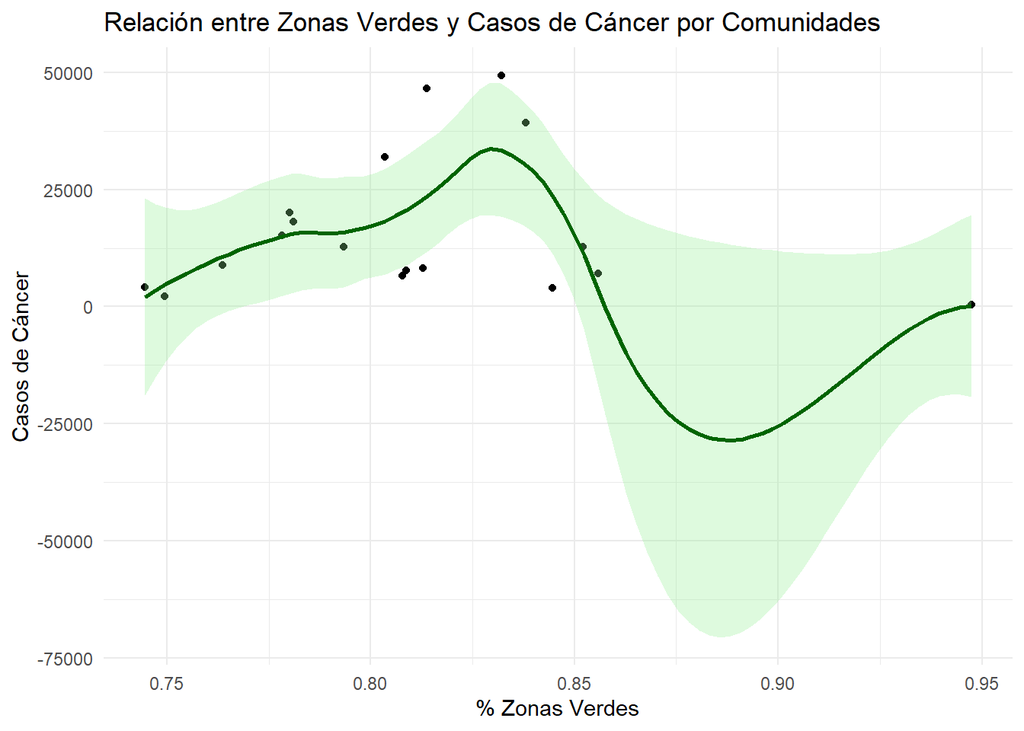

```r
grafico_zonas_verdes_cancer <- ggplot(zonasverdes_cancer, aes(x = porcentajeverde, y = casos_cancer)) +
  geom_point() +
  labs(
    title = "Relación entre Zonas Verdes y Casos de Cáncer por Comunidades",
    x = "% Zonas Verdes",
    y = "Casos de Cáncer"
  ) +
  geom_smooth(method = "loess", formula = y ~ x, color = "darkgreen", fill = "lightgreen", alpha = 0.3)+
  theme_minimal()
grafico_zonas_verdes_cancer
```

Como podemos observar, este gráfico presenta muchas subidas y bajadas en los casos de cáncer según sube el porcentaje de índice verde,lo cual nos permite determinar que no tiene nada que ver el factor ambiental. Es decir, el porcentaje verde de la zona en la que vivas con la posibilidad que tienes de desarrollar o no cáncer.

### Tiene más influencia lo llamado bueno o lo malo sobre la influencia del cancer

Generalmente se tiende a decir que teniendo buenos hábitos de vida y viviendo en zonas no contaminadas disminuye el riesgo de padecer enfermedades, pero realmente, no se sabe si esto tiene más peso que aquellos factores conocidos como factores malos, como por ejemplo el alcohol. Hemos realizado un gráfico para comprobar si se produce mayor disminución del riesgo de padecer cáncer a mayor porcentaje de actividad física y porcentaje verde, o si el alcohol tiene más peso sobre esto.

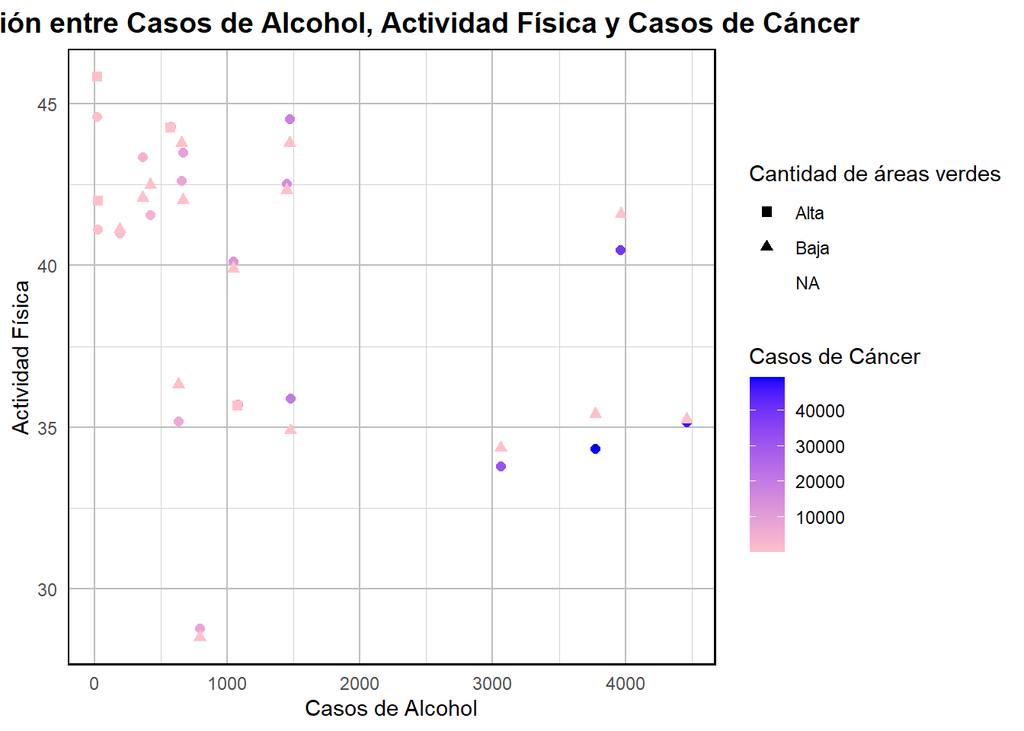

```r
cancer_completo$casos_cancer <- as.numeric(as.character(cancer_completo$casos_cancer))
cancer_completo$shape_porcentajeverde <- ifelse(cancer_completo$porcentajeverde > 0.85, "Alta", "Baja")
cancer_completo <- cancer_completo[!is.na(cancer_completo), ]

grafico_final <- ggplot(cancer_completo, aes(x = casos_alcohol, y = actividad)) +
  geom_point(aes(colour = casos_cancer), shape = 16, size = 2, position = position_jitter(width = 1.3, height = 1.3)) +
  geom_point(aes(x = casos_alcohol, y = actividad, shape = shape_porcentajeverde, color = porcentajeverde), size = 2, position = position_jitter(width = 0.2, height = 0.2)) +
  scale_shape_manual(values = c("Alta" = 15, "Baja" = 17)) +
  scale_color_gradient(low = "pink", high = "blue", name = "Casos de Cáncer") +
  labs(
    title = "Relación entre Casos de Alcohol, Actividad Física y Casos de Cáncer",
    x = "Casos de Alcohol",
    y = "Actividad Física",
    shape = "Cantidad de áreas verdes"
  ) +
  theme_minimal() +
  theme(
    plot.title = element_text(hjust = 0.5, face = "bold", size = 14),
    panel.border = element_rect(color = "black", fill = NA, size = 0.8),
    panel.grid.major = element_line(color = "gray", size = 0.5),
    panel.grid.minor = element_line(color = "lightgray", size = 0.25)
  )
grafico_final
```

En este único gráfico podemos observar los casos de cáncer en España y su relación con todas las variables que estamos estudiando a la vez. Como hemos afirmado observando los gráficos anteriores, la cantidad de población que realiza actividad física es inversamente proporcional a la cantidad de personas que padecen cáncer. En el caso de los datos sobre alcohol, concluimos que es la variable que más afecta, ya que vemos que las comuniades que más casos de alcoholismo tienen prácticamente son las más altas en casos de cáncer, sin casi excepciones. Por último, vemos que la variable de zonas verdes es la que menos influye, ya que las comunidades con la tasa de zonas verdes más alta tiene números de cáncer muy variados.  
Después de sacar estas conclusiones, hemos decidido realizar un último gráfico en el que se muestren únicamente las dos variables que más afectan a nuestro estudio, para que sea más visual.

```r
variables_influyentes <- left_join(
  alcohol_cancer %>% select(Comunidad_autonoma, casos_alcohol, casos_cancer),
  actividad_cancer %>% select(Comunidad_autonoma, actividad),
  by = "Comunidad_autonoma"
)
variables_influyentes
```

```
##      Comunidad_autonoma casos_alcohol casos_cancer actividad
## 1             Andalucia        3775.2        49387      35.3
## 2                Aragon         667.3         8889      42.2
## 3              Asturias         654.1         7762      43.7
## 4        Islas_Baleares         632.2         6511      36.2
## 5        Islas_Canarias        1079.1        12739      35.7
## 6             Cantabria         364.4         4041      42.2
## 7       Castilla_y_Leon        1473.9        18188      43.7
## 8     Castilla_LaMancha        1048.5        12767      40.0
## 9              Cataluna        4458.7        46630      35.3
## 10 Comunidad_Valenciana        3058.5        31928      34.2
## 11          Extremadura         574.1         7032      44.1
## 12              Galicia        1477.1        20135      35.0
## 13               Madrid        3964.9        39203      41.5
## 14               Murcia         796.0         8259        NA
## 15              Navarra         424.0         4175        NA
## 16           Pais_Vasco        1451.0        15170      42.3
## 17                Rioja         192.7         2115      41.2
## 18                Ceuta          27.0          380      41.9
## 19              Melilla          21.1          363      45.7
```

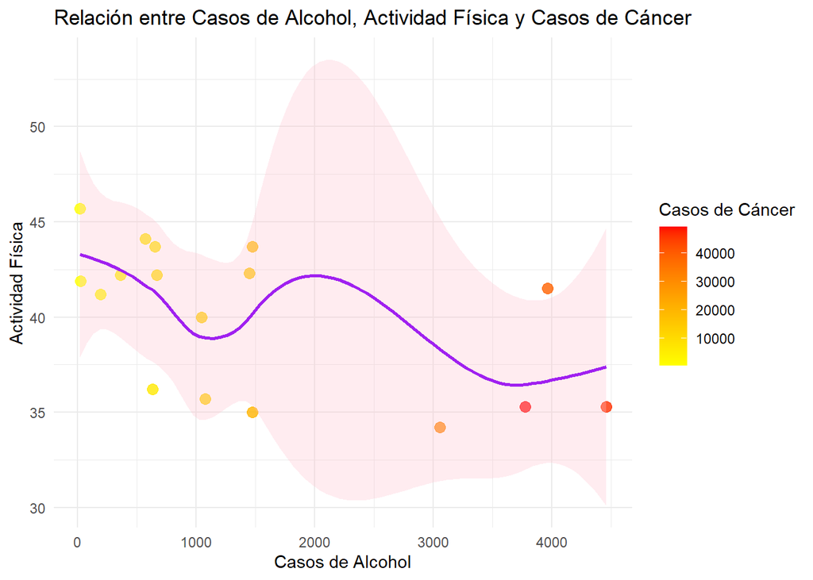

```r
variables_influyentes<- na.omit(variables_influyentes)
grafico_variables_influyentes <- ggplot(variables_influyentes, aes(x = casos_alcohol, y = actividad, color = casos_cancer)) +
  geom_point(size = 3, alpha = 0.8) +
  geom_smooth(method = "loess", formula = y ~ x, color = "purple", fill = "pink", alpha = 0.3) +
  scale_color_gradient(low = "yellow", high = "red", name = "Casos de Cáncer") +
  labs(
    title = "Relación entre Casos de Alcohol, Actividad Física y Casos de Cáncer",
    x = "Casos de Alcohol",
    y = "Actividad Física"
  ) +
  theme_minimal()

grafico_variables_influyentes
```

### Conclusiones finales

Como conclusión final diremos que el alcohol es la variable que más afecta al cáncer con bastante diferencia, incluso más que las dos variables que consideramos “buenas” juntas.

Consideramos que poder ver estos datos representados a modo de gráficos facilitan mucho su interpretación. Esto puede venir bien para concienciar a la población de esta enfermadad tan común en los últimos años y poder realmente replantearnos el estilo de vida que queremos llevar.

###Pregunta extra Dejando a un lado los casos de cáncer, queremos realizar un pequeño estudio de los hábitos de la población. Para ello, relacionaremos las variables de ejercicio físico realizado con las personas que toman alcohol. Las dos variables serán estudiadas por comunidades, para poder tomar conclusiones y responder a esta pregunta: * ¿El alcohol te lleva indirectamente al sedentarismo o es compaginable con buenos hábitos como el deporte?

```r
pregunta_extra <- left_join(
  alcohol_cancer %>% select(Comunidad_autonoma, casos_alcohol),
  actividad_cancer %>% select(Comunidad_autonoma, actividad),
  by = "Comunidad_autonoma"
)
pregunta_extra<- na.omit(pregunta_extra)
pregunta_extra
```

```
##      Comunidad_autonoma casos_alcohol actividad
## 1             Andalucia        3775.2      35.3
## 2                Aragon         667.3      42.2
## 3              Asturias         654.1      43.7
## 4        Islas_Baleares         632.2      36.2
## 5        Islas_Canarias        1079.1      35.7
## 6             Cantabria         364.4      42.2
## 7       Castilla_y_Leon        1473.9      43.7
## 8     Castilla_LaMancha        1048.5      40.0
## 9              Cataluna        4458.7      35.3
## 10 Comunidad_Valenciana        3058.5      34.2
## 11          Extremadura         574.1      44.1
## 12              Galicia        1477.1      35.0
## 13               Madrid        3964.9      41.5
## 16           Pais_Vasco        1451.0      42.3
## 17                Rioja         192.7      41.2
## 18                Ceuta          27.0      41.9
## 19              Melilla          21.1      45.7
```

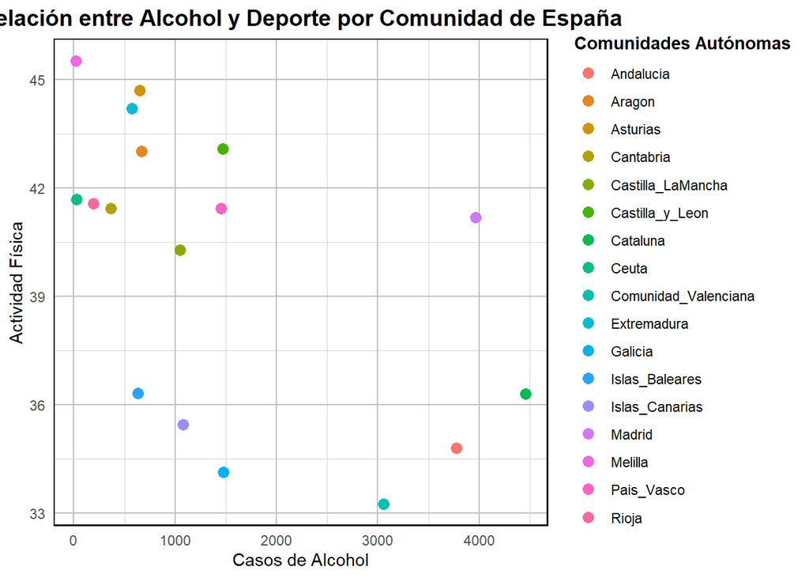

```r
grafico_pregunta_extra <- ggplot(pregunta_extra, aes(x = casos_alcohol, y = actividad)) +
  geom_point(aes(colour = Comunidad_autonoma), size = 3, position = position_jitter(width = 1, height = 1)) +
  scale_color_discrete(name = "Comunidades Autónomas") +
  labs(
    title = "Relación entre Alcohol y Deporte por Comunidad de España",
    x = "Casos de Alcohol",
    y = "Actividad Física"
  ) +
  theme_minimal() +
  theme(
    plot.title = element_text(hjust = 0.5, face = "bold", size = 14),
    panel.border = element_rect(color = "black", fill = NA, size = 0.8),
    panel.grid.major = element_line(color = "gray", size = 0.5),
    panel.grid.minor = element_line(color = "lightgray", size = 0.25),
    legend.title = element_text(face = "bold"),
    legend.position = "right"
  )

grafico_pregunta_extra
```

En este gráfico podemos observar cada Comunidad Autónoma de España con un color diferente para que sea más rápido visualizar sus casos de alcohol y deporte.

Para observar si puede tener algo de relación con esto la temperatura media de las comunidades, voy a agruparlas por regiones diferenciando el norte del país, el centro y el sur, donde la temperatura es similar.

```r
pregunta_extra_clasificada <- pregunta_extra %>%
  dplyr::mutate(region = dplyr::case_when(
    Comunidad_autonoma %in% c(
      "Galicia", "Asturias", "Cantabria", "Pais_Vasco", "Navarra",
      "Cataluna", "Rioja", "Castilla_y_Leon", "Aragon"
    ) ~ "Norte de España",
    Comunidad_autonoma %in% c(
      "Extremadura", "Castilla_LaMancha", "Comunidad_Valenciana",
      "Islas_Baleares", "Madrid"
    ) ~ "España centro",
    Comunidad_autonoma %in% c(
      "Andalucia", "Murcia", "Ceuta", "Melilla", "Islas_Canarias"
    ) ~ "Sur de España"
  ))
pregunta_extra_clasificada
```

```
##      Comunidad_autonoma casos_alcohol actividad          region
## 1             Andalucia        3775.2      35.3   Sur de España
## 2                Aragon         667.3      42.2 Norte de España
## 3              Asturias         654.1      43.7 Norte de España
## 4        Islas_Baleares         632.2      36.2   España centro
## 5        Islas_Canarias        1079.1      35.7   Sur de España
## 6             Cantabria         364.4      42.2 Norte de España
## 7       Castilla_y_Leon        1473.9      43.7 Norte de España
## 8     Castilla_LaMancha        1048.5      40.0   España centro
## 9              Cataluna        4458.7      35.3 Norte de España
## 10 Comunidad_Valenciana        3058.5      34.2   España centro
## 11          Extremadura         574.1      44.1   España centro
## 12              Galicia        1477.1      35.0 Norte de España
## 13               Madrid        3964.9      41.5   España centro
## 16           Pais_Vasco        1451.0      42.3 Norte de España
## 17                Rioja         192.7      41.2 Norte de España
## 18                Ceuta          27.0      41.9   Sur de España
## 19              Melilla          21.1      45.7   Sur de España
```

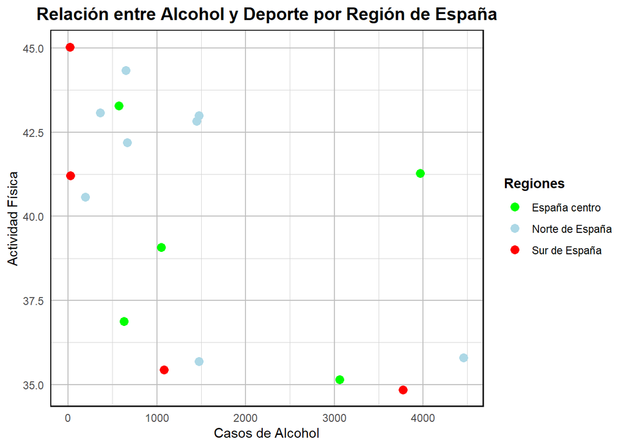

```r
grafico_clasificado <- ggplot(pregunta_extra_clasificada, aes(x = casos_alcohol, y = actividad)) +
  geom_point(aes(colour = region), size = 3, position = position_jitter(width = 1, height = 1)) +
  scale_color_manual(
    values = c(
      "Norte de España" = "lightblue",
      "España centro" = "green",
      "Sur de España" = "red"
    ),
    name = "Regiones"
  ) +
  labs(
    title = "Relación entre Alcohol y Deporte por Región de España",
    x = "Casos de Alcohol",
    y = "Actividad Física"
  ) +
  theme_minimal() +
  theme(
    plot.title = element_text(hjust = 0.5, face = "bold", size = 14),
    panel.border = element_rect(color = "black", fill = NA, size = 0.8),
    panel.grid.major = element_line(color = "gray", size = 0.5),
    panel.grid.minor = element_line(color = "lightgray", size = 0.25),
    legend.title = element_text(face = "bold"),
    legend.position = "right"
  )

grafico_clasificado
```

Para este análisis debemos despreciar un poco grandes comunidades como son Madrid, Cataluña, Andalucía y Valencia (los más alejados a la derecha del gráfico), ya que los datos de alcohol y deporte no están en porcentaje con el número de población, por lo que al ser comunidades muy grandes y pobladas siempre van a dar los mayores números y no podríamos hacer una buena comparación entre comunidades. Ocurre lo mismo con Ceuta y Melilla (los dos puntos rojos de la izquierda del todo), pero al contrario, debemos despreciarlas por ser muy pequeñas.

Observando este gráfico podemos decir que por lo general (no sabemos si por la temperatura o por otro factor), en el norte de España la población realiza mucho deporte y en el sur bastante poco. A nivel de alcohol están bastante compensadas las tres regiones por lo que la temperatura concluimos que no afecta demasiado. Existirán otros múltiples factores que afecten. Para observarlos, tendríamos que realizar un estudio más exahustivo con diferentes variables y muchos más datos.

Con todo este análisis final refuerzo la conclusión que sacamos antes: El alcohol sí influye en la realización de ejercicio físico, es un mal hábito que suele privarte de tener otros hábitos buenos. Pero no lo es en una gran medida, ya que vemos que sí hay comunidades con alto consumo de alcohol y alto nivel de deporte.

Finalizo con la opinión personal de que si mantienes el consumo de alcohol controlado para ocasiones puntuales y tienes una buena fuerza de voluntad podrás realizar deporte y otros buenos hábitos relacionados sin ningún problema.

[output not shown]